# groupADA

## **7. Comparing results & choosing solution**

- **Hierarchical clustering Model**

-Fitting Hierarchical clustering Model to dataset

```r
set.seed(240)  # Setting seed
Hierar_cl_fa3 <- hclust(distance_mat_fa3, method = "ward.D")
Hierar_cl_fa3
```

```
##
## Call:
## hclust(d = distance_mat_fa3, method = "ward.D")
##
## Cluster method   : ward.D
## Distance         : euclidean
## Number of objects: 500
```

-Plotting dendrogram

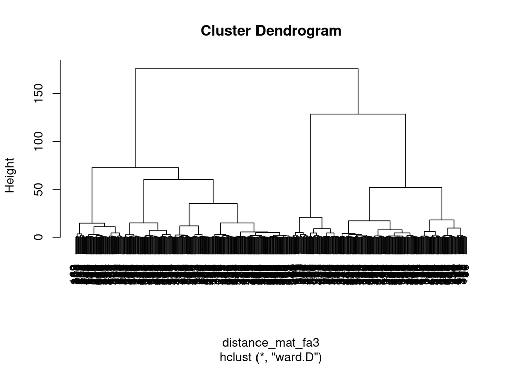

```r
plot(Hierar_cl_fa3)
```

-Choosing no. of clusters (3 clusters)

```r
fit_fa3 <- cutree(Hierar_cl_fa3, k = 3 )
fit_fa3
```

```
##   [1] 1 2 2 1 2 2 2 2 2 1 3 1 1 1 2 2 3 2 1 2 1 3 2 2 1 3 2 1 2 2 2 1 2 1 1 2 2
##  [38] 1 2 3 1 2 2 2 2 1 1 1 2 3 1 2 3 1 2 3 2 3 3 2 2 2 2 2 2 2 2 1 1 2 2 2 3 2
##  [75] 2 2 2 2 3 2 2 1 2 2 2 1 1 1 2 1 2 1 2 1 1 1 2 3 3 1 2 2 1 3 2 2 1 1 3 1 2
## [112] 2 2 2 1 2 2 2 1 2 2 1 1 1 3 1 2 1 3 2 2 2 3 1 2 2 2 1 1 3 2 1 1 2 1 1 1 2
## [149] 2 2 1 1 1 1 2 1 1 2 2 2 1 2 3 3 1 2 2 1 2 2 2 1 1 3 2 2 2 2 2 2 1 2 1 2 3
## [186] 1 2 2 1 2 1 2 1 2 2 2 2 2 2 2 2 1 1 2 2 2 2 1 2 2 2 1 1 2 1 1 1 1 2 3 2 1
## [223] 2 2 2 1 3 2 2 2 2 3 2 1 2 2 2 1 2 2 1 2 2 2 2 1 2 2 1 2 1 2 1 1 2 2 2 2 3
## [260] 3 1 2 2 2 2 2 2 1 2 1 2 1 2 1 2 2 1 3 1 2 1 2 2 1 2 2 2 2 3 1 1 2 2 2 1 2
## [297] 2 3 1 2 2 2 2 2 2 3 2 2 3 2 2 3 3 2 1 2 2 1 3 1 2 1 2 2 1 3 2 2 2 2 2 2 3
## [334] 1 1 3 2 1 1 2 1 1 1 1 3 2 3 1 2 1 2 2 2 1 2 2 2 2 3 2 2 3 1 1 2 1 1 2 2 2
## [371] 2 2 2 2 1 3 2 2 1 2 2 2 1 3 2 2 2 1 1 2 2 1 2 2 1 2 2 3 3 2 1 2 1 2 1 1 1
## [408] 2 1 1 2 1 2 2 1 1 2 2 2 2 2 2 1 2 2 1 3 2 2 3 1 2 1 1 1 1 2 3 3 1 1 2 2 2
## [445] 2 2 2 2 1 2 2 3 2 2 1 2 3 3 3 2 2 2 1 1 1 3 1 1 2 2 1 2 1 2 1 1 1 2 2 2 1
## [482] 2 1 2 2 3 2 2 2 2 2 3 2 2 2 1 1 1 3 2
```

-Find number of observations in each cluster

```r
table(fit_fa3)
```

```
## fit_fa3
##   1   2   3
## 163 277  60
```

```r
final_data_fa3 <-cbind(sample_s, cluster = fit_fa3)
```

-Display first six rows of final data

```r
head(final_data_fa3)
```

```
##             PA1        PA2 cluster
## [1,] -0.1837921 -1.0875018       1
## [2,] -1.2801680 -0.3512067       2
## [3,] -1.8763213  0.5404125       2
## [4,]  0.2015468 -0.5554284       1
## [5,] -0.7518820  1.5114189       2
## [6,] -0.0306106  1.9569939       2
```

-Find mean values for each cluster

```r
hcentres_fa3<-aggregate(x=final_data_fa3, by=list(cluster=fit_fa3), FUN="mean")
print(hcentres_fa3)
```

```
##   cluster        PA1        PA2 cluster
## 1       1  0.5967203 -0.9183870       1
## 2       2 -0.6591268  0.2544071       2
## 3       3  1.4218784  1.3204386       3
```

- **Non-hierarchical clustering Model (Kmeans)**

```r
# 3 clusters
set.seed(55)
k_cl_fa3 <- kmeans(sample_s, 3, nstart=25)
k_cl_fa3
```

```
## K-means clustering with 3 clusters of sizes 93, 187, 220
##
## Cluster means:
##          PA1        PA2
## 1  1.1785205  1.1181371
## 2  0.4430026 -0.8371817
## 3 -0.8747450  0.2389374
##
## Clustering vector:
##   [1] 2 3 3 2 3 1 3 3 3 2 1 2 2 2 3 3 1 3 2 1 1 1 3 3 2 1 2 2 3 3 3 2 3 2 2 3 3
##  [38] 2 3 1 2 3 3 1 3 2 2 2 3 1 2 3 1 2 3 1 2 1 1 3 3 3 3 2 1 3 3 2 1 3 2 2 1 1
##  [75] 1 3 3 3 1 3 3 2 3 3 3 2 2 2 3 2 3 2 3 2 2 1 3 1 1 2 3 3 2 1 3 3 1 2 1 2 3
## [112] 3 1 3 2 1 3 3 2 3 3 2 2 2 1 2 3 2 1 2 3 3 1 2 3 3 3 2 2 1 3 2 2 2 2 2 2 3
## [149] 3 3 2 2 2 2 3 2 2 3 1 3 2 3 1 1 1 3 3 2 3 2 3 2 2 1 2 3 3 3 3 3 2 3 2 2 1
## [186] 2 3 3 1 3 2 3 2 3 3 3 3 3 2 3 3 2 2 1 3 3 3 2 1 3 1 2 2 3 2 2 2 2 3 1 3 2
## [223] 1 3 3 2 1 3 1 3 3 1 3 2 3 3 3 2 3 3 2 3 3 3 3 2 3 3 2 3 1 3 2 2 3 3 3 3 1
## [260] 1 2 3 3 3 3 3 3 2 2 2 3 2 3 2 3 3 2 1 2 2 2 3 3 2 1 3 2 3 1 2 2 3 3 2 2 3
## [297] 1 1 2 3 2 3 3 3 3 1 3 2 1 3 3 1 1 2 1 3 3 2 1 2 2 2 3 3 2 1 2 1 3 3 3 3 1
## [334] 2 2 1 3 2 2 3 2 2 2 2 1 3 1 2 3 2 3 3 3 2 3 3 3 3 1 1 1 1 2 2 3 2 2 2 3 2
## [371] 3 3 3 3 2 1 3 3 2 3 3 3 2 1 3 3 2 2 2 3 3 2 3 3 1 3 3 1 1 2 2 2 2 3 2 2 2
## [408] 3 2 2 3 2 3 3 2 2 3 1 2 3 1 3 2 2 3 2 1 1 3 1 2 3 2 2 2 2 3 1 1 2 2 3 3 3
## [445] 3 3 3 3 2 3 3 1 3 3 2 3 1 1 1 3 2 2 2 2 2 1 2 2 3 3 2 2 2 2 1 2 2 3 1 3 2
## [482] 3 2 3 2 1 3 3 3 3 3 1 2 2 3 2 2 2 1 3
##
## Within cluster sum of squares by cluster:
## [1] 107.2371 107.8363 188.8248
##  (between_SS / total_SS =  59.5 %)
##
## Available components:
##
## [1] "cluster"      "centers"      "totss"        "withinss"     "tot.withinss"
## [6] "betweenss"    "size"         "iter"         "ifault"
```

### **7.1. Choose final cluster solution**

- **Similarity measure**
- Using Silhouette Coefficient Index to compare hierarchical and Non-hierarchical solutions

```r
# Hierarchical model
silhouette_score_hierar <- silhouette(fit_fa3, dist(sample_s))
avg_sil_width_hierar <- mean(silhouette_score_hierar[, 'sil_width'])

# Non-hierarchical model  (K-means)
silhouette_score_kmeans <- silhouette(k_cl_fa3$cluster, dist(sample_s))
avg_sil_width_kmeans <- mean(silhouette_score_kmeans[, 'sil_width'])

# Compare Silhouette Coefficient Index
print(paste("Hierarchical clustering average silhouette width:", avg_sil_width_hierar))
```

```
## [1] "Hierarchical clustering average silhouette width: 0.365886930628537"
```

```r
print(paste("K-means clustering average silhouette width:", avg_sil_width_kmeans))
```

```
## [1] "K-means clustering average silhouette width: 0.385485019803922"
```

Based on the result above, non-hierarchical model has a higher Silhouette Coefficient Index, which means clusters are closely connected within each other, while clusters are relatively separated from each other.

```
##   cluster size ave.sil.width
## 1       1  163          0.44
## 2       2  277          0.30
## 3       3   60          0.49
```

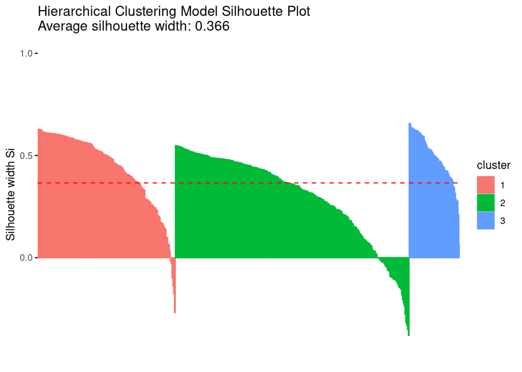

```r
# Silhouette plot
fviz_silhouette(silhouette_score_hierar) +
    ggtitle(paste("Hierarchical Clustering Model Silhouette Plot\nAverage silhouette width:", round(avg_sil_width_hierar, 3)))
```

```
##   cluster size ave.sil.width
## 1       1   93          0.33
## 2       2  187          0.44
## 3       3  220          0.36
```

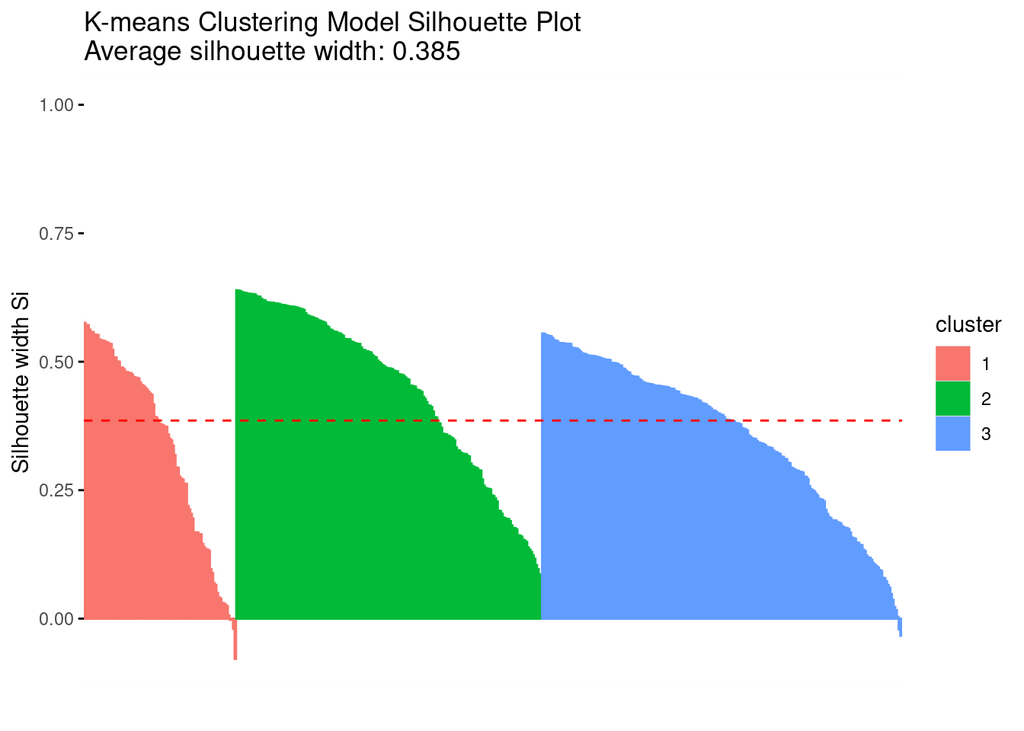

```r
fviz_silhouette(silhouette_score_kmeans) +
    ggtitle(paste("K-means Clustering Model Silhouette Plot\nAverage silhouette width:", round(avg_sil_width_kmeans, 3)))
```

According to these two figures, the K-means clustering model provides better clustering quality, with higher average silhouette width and more consistent intra-group similarity. In hierarchical clustering model, it can be seen that many samples, in cluster 1 and 2, have a negative silhouette coefficient. This means that they are not in the right cluster.

Hence, we choose to use K-means clustering (3 clusters) solution in our case.